# Ejercicios UMAP

*Aprendizaje máquina II*

*Curso 2023-2024*

Authors:

- Rubén Castillo Carrasco

- Manuel Rubio Martínez

- Instalar umap-learn y densmap-learn.
- Descargar el dataset de Fashion MNIST del siguiente enlace:

  https://github.com/zalandoresearch/fashion-mnist

  Tendrás que descomprimir los ficheros *gz para que el código funcione. Asegúrate que el path utilizado para cargar los datos sea el correcto.

## 1. UMAP en Fashion MNIST

Primero realizaremos una reducción de dimensionalidad no supervisada mediante UMAP. Estableceremos el número de vecinos en 5 porque estamos interesados solo en la información local. Reduciremos el número de dimensiones a 2.

```python
import numpy as np
import matplotlib.pyplot as plt
%matplotlib inline
import seaborn as sns
from mnist import MNIST
import sklearn.datasets
import umap
sns.set(style='white', context='poster')

from sklearn.model_selection import train_test_split
```

Se carga el conjunto de datos usando `fetch_openml` en lugar del metodo indicado, al presentar problemas este último.

```python
mndata=sklearn.datasets.fetch_openml("Fashion-MNIST")
X_train, X_test, y_train, y_test = train_test_split(
    mndata.data, mndata.target, test_size=0.2, random_state=42
)
data=mndata.data
target=mndata.target
```

```python
classes = [
    'T-shirt/top',
    'Trouser',
    'Pullover',
    'Dress',
    'Coat',
    'Sandal',
    'Shirt',
    'Sneaker',
    'Bag',
    'Ankle boot']


embedding2 = umap.UMAP(n_neighbors=5).fit_transform(data)
```

Se representa el embedding obtenido mediante UMAP

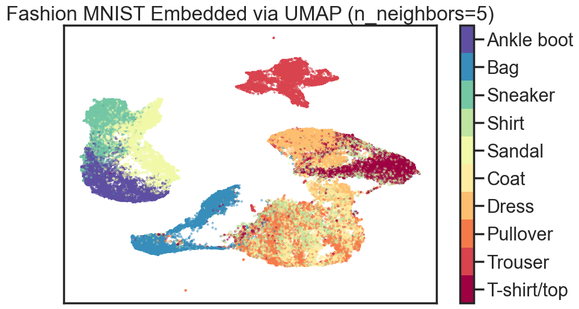

```python
fig, ax = plt.subplots(1, figsize=(10, 6))
#colores=['blue','red','green','magenta','black','yellow','cyan','purple','pink','brown']
target=np.array(target).astype(int)
#lista = [colores[t] for t in target]

plt.scatter(*embedding2.T, s=0.3, c=np.array(target), cmap='Spectral', alpha=1.0)
plt.setp(ax, xticks=[], yticks=[])
cbar = plt.colorbar(boundaries=np.arange(11)-0.5)
cbar.set_ticks(np.arange(10))
cbar.set_ticklabels(classes)
plt.title('Fashion MNIST Embedded via UMAP (n_neighbors=5)')
```

Se observa que, pese a haber clases claramente diferenciadas respecto al resto, como puede ser `trouser`, muchas otras, como `t-shirt` y `dress` quedan entremezcladas en el embedding obtenido mediante UMAP. Para tratar de mejorar los resultados, hacemos uso de DensMap.

Aplicamos DensMAP para comparar los resultados con el algoritmo UMAP clásico.

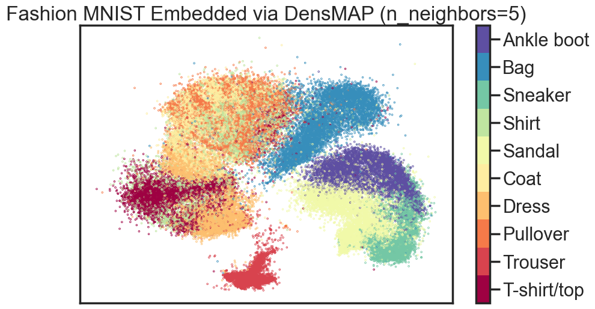

```python
mapper = umap.UMAP(densmap=True, n_neighbors=5).fit(data)

fig, ax = plt.subplots(1, figsize=(10, 6))
plt.scatter(*mapper.embedding_.T, s=0.3, c=np.array(target), cmap='Spectral', alpha=1.0)
plt.setp(ax, xticks=[], yticks=[])
cbar = plt.colorbar(boundaries=np.arange(11)-0.5)
cbar.set_ticks(np.arange(10))
cbar.set_ticklabels(classes)
plt.title('Fashion MNIST Embedded via DensMAP (n_neighbors=5)');
```

Se observa que los resultados obtenidos mediante el modelo son aun peores que con el anterior, dando lugar a un embedding donde las clases estan mas juntas entre sí y además existen clases entremezcladas entre sí. Por ello, en la siguiente aproximación haremos uso de variantes semi-supervisadas para la obtención del embedding.

## 2. Utilizando etiquetas para separar clases (Supervised UMAP)

Para realizar esta versión supervisada de UMAP introduciremos las etiquetas en el parámetro 'y' de la función 'fit' de UMAP. En este caso se utilizará un número mayor de vecinos (podemos poner 15). UMAP también permite hacer hacer aprendizaje semi-supervisado.

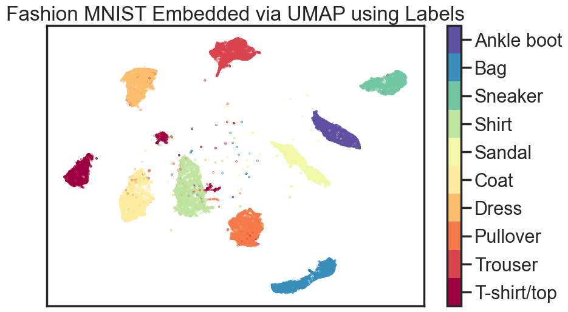

```python
embedding = umap.UMAP(n_neighbors=15).fit_transform(data, y=target)

fig, ax = plt.subplots(1, figsize=(10, 6))
plt.scatter(*embedding.T, s=0.1, c=target, cmap='Spectral', alpha=1.0)
plt.setp(ax, xticks=[], yticks=[])
cbar = plt.colorbar(boundaries=np.arange(11)-0.5)
cbar.set_ticks(np.arange(10))
cbar.set_ticklabels(classes)
plt.title('Fashion MNIST Embedded via UMAP using Labels');
```

Aplicamos el algoritmo DensMAP para comparar con el UMAP clásico en sus variantes semi-supervisadas:

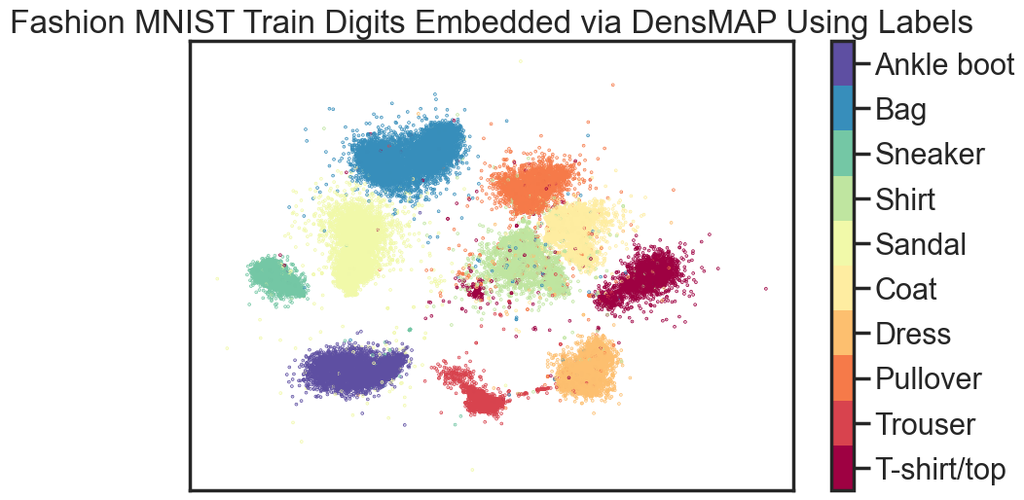

```python
mapper = umap.UMAP(densmap=True, n_neighbors=15).fit(data, np.array(target))

fig, ax = plt.subplots(1, figsize=(10, 6))
plt.scatter(*mapper.embedding_.T, s=0.3, c=np.array(target), cmap='Spectral', alpha=1.0)
plt.setp(ax, xticks=[], yticks=[])
cbar = plt.colorbar(boundaries=np.arange(11)-0.5)
cbar.set_ticks(np.arange(10))
cbar.set_ticklabels(classes)
plt.title('Fashion MNIST Train Digits Embedded via DensMAP Using Labels');
```

En cuanto a `DenseMap` semi-supervisado, los resultados mejoran de forma significativa frente a su variante no supervisada. En cambio, los resultados no mejoran a los de `UMAP` semi-supervisado para el conjunto de datos dado.

## 3. Entrenamiento con etiquetas y embedding con test no etiquetado (Metric Learning with UMAP)

Veamos como se puede utilizar UMAP en aprendizaje métrico, es decir, aprender un embedding supervisado de los datos y utilizar datos nuevos para clasificar a partir de una métrica aprendida como una medida de la distancia entre nuevos puntos no etiquetados. Este procedimiento no lo podemos aplicar con DensMAP porque DensMAP no permite transformar datos a un "embedding" entrenado con otro dataset (train), por lo que utilizarem UMAP clásico.

Para ello utiliza la división entre train y test proporcionada por Fashion MNIST y visualiza los resultados.

```python
mapper = umap.UMAP( n_neighbors=5).fit(X_train, np.array(y_train))

mapper_test =  mapper.transform(X_test)
```

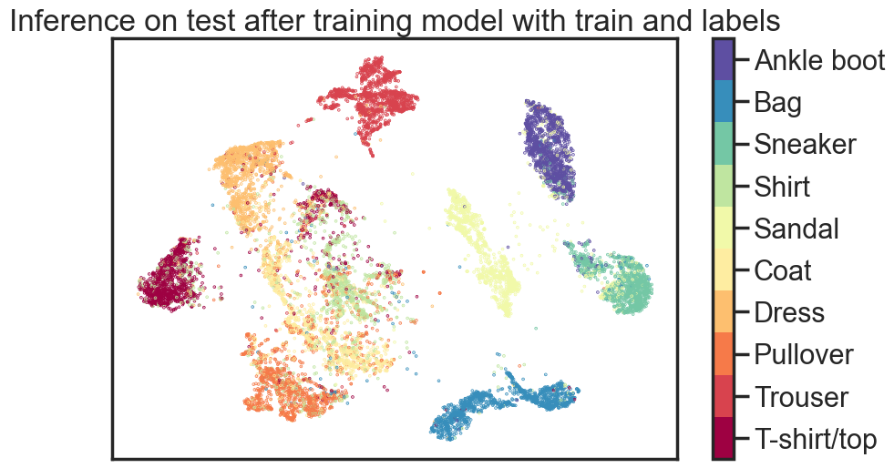

```python
fig, ax = plt.subplots(1, figsize=(10, 6))
plt.scatter(*mapper_test.T, s=0.3, c=np.array(y_test).astype(int), cmap='Spectral', alpha=1.0)
plt.setp(ax, xticks=[], yticks=[])
cbar = plt.colorbar(boundaries=np.arange(11)-0.5)
cbar.set_ticks(np.arange(10))
cbar.set_ticklabels(classes)
plt.title('Inference on test after training model with train and labels');
```

Como resultado se tiene que, haciendo uso de un entrenamiento etiquetado, al representar un conjunto de test no etiquetado, el embedding resultante mantiene, en general, las distancias entre clases a pesar de que el modelo no acceda a sus etiquetas para el entrenamiento, aunque en un número reducido de clases no logra separar de forma correcta las instancias. En cambio, en embedding resultante no mantiene tanto las distancias como el que representa al train etiquetado, como es lógico y era de esperar.